# S4 examples

Date: 2022-11-17

## Motivation of using `S4`

- Usually we have the needed information in multiple tables, an easy way to have all information in one object is by merging tables.
- But sometimes we need to work with objects that cannot be easily merged: `data.frames` with nested `list`s.
- Repeat similar operations over a set of IDs, sometimes the metadata of one ID is non-available (this may cause information lose when merging tables).

## `S4` class objects

- One type of the `R` object oriented (*OO*) systems (other OO systems are `S3` and `R6`).
- `S4` allows a formal and strict class definition and inheritance.

## Why to use `S4` ?

- `S4` is a rigorous system that forces you to think carefully about program design.
- It’s well-suited for building large systems that evolve over time and will receive contributions from many programmers.
- It is used by the Bioconductor project.

## *Class* properties

- **Name**
- **Representation** : list of slots (fields)
- **Inheritance** : classes associated to the slots.

## Protease cleavage

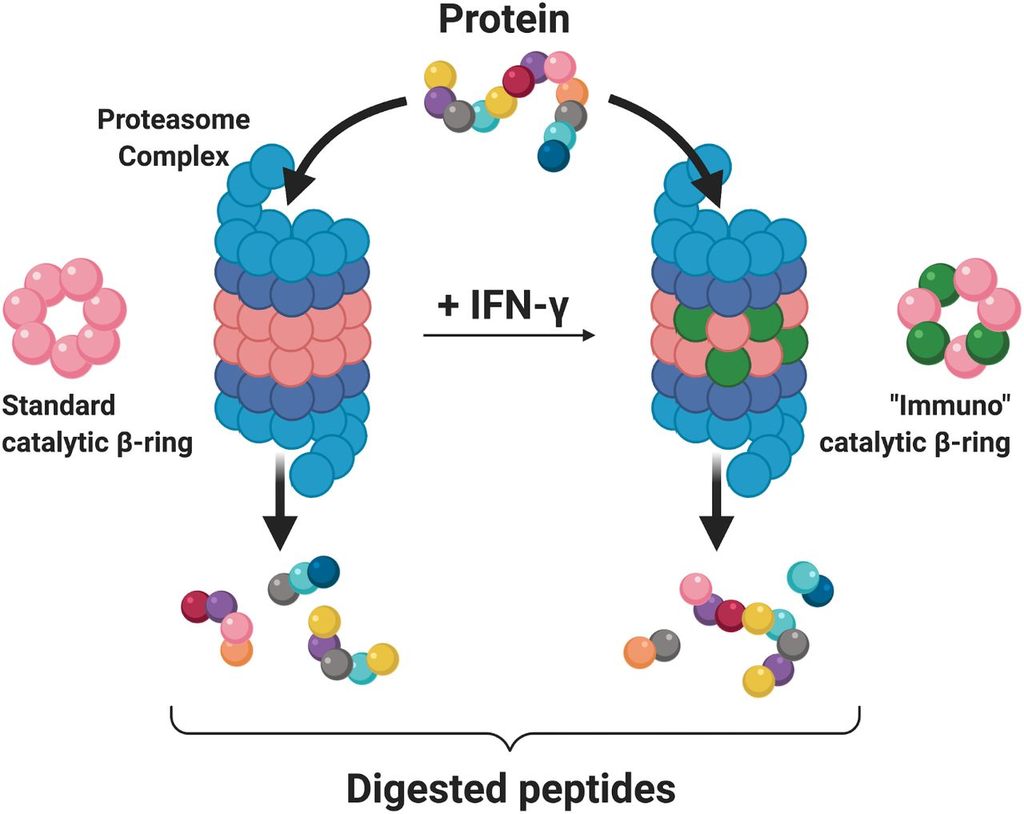

Weeder BR et al 2021. pepsickle rapidly and accurately predicts proteasomal cleavage sites for improved neoantigen identification.

## Vaccine construct

- The selected epitopes are inserted in an array.
- In many cases, linker sequences are inserted between epitopes.

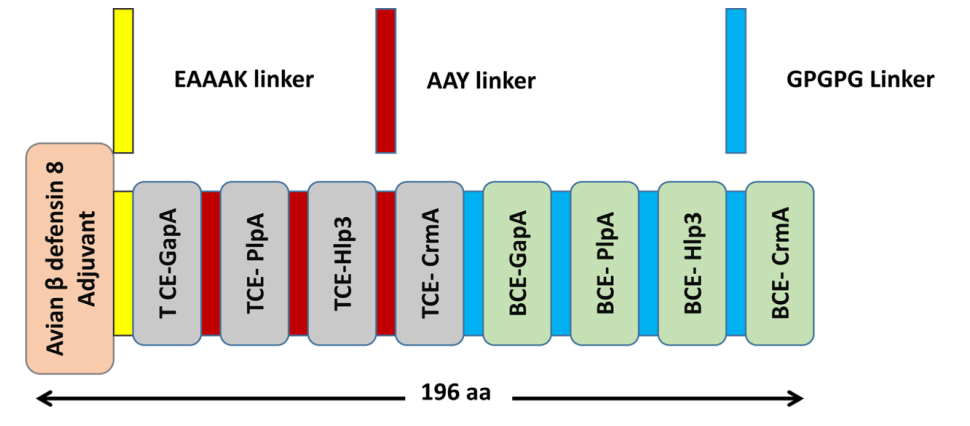

Mugunthan SP & Harish MC, 2021. Multi-epitope-Based Vaccine Designed by Targeting Cytoadherence Proteins of Mycoplasma gallisepticum.

## Example of `S4` class definition

```r
setClass("ProteasomeCleavage",

  # Slots (a.k.a fields) with their classes
  slots = c(id                 = "character",
            sequence           = "character",
            cleavage_threshold = "numeric",
            nb_sites           = "numeric",
            fragments_imm      = "data.table"),

  # Initialize slots
  prototype = list(id                 = NA_character_,
                   sequence           = NA_character_,
                   cleavage_threshold = 0.5,
                   nb_sites           = NA_real_,
                   fragments_imm      = data.table())
)
```

## *Validity* function

- By definition `S4` classes are strictly defined, but additionally, we could create a *validity* functions to evaluate wheter the content in each slot is valid according to our criteria.
- *Validity* functions are launched each time a `S4` object is updated (created, modified).

## Take-home messages

- Working with `S4` class objects makes you think in advance when you are programming.
- It is very suitable for long-term projects involving many programmers.
- Although more verbose than other OO systems, it has the advantage of validate the content, which may be very useful to avoid bugs or unexpected behavior.

## Further reading

This is just an introduction, other `S4`-related topics (such herritability) were not included pin this presentation but can be found in the following sources.

- [Object-oriented R](https://adv-r.hadley.nz/oo.html)
- [OO essentials](http://adv-r.had.co.nz/OO-essentials.html)
- [S4](http://adv-r.had.co.nz/S4.html)